# Analysis of global trends in coffee trade

## Introduction

Coffee is a major part of many people's daily life. In fact, it is the third most popular drink in the world, beside water and tea, with over one billion people drinking coffee daily. Despite it's popularity, coffee can only be grown in within a region called the 'Coffee Belt' — a region roughly between 25° North and 30° South of the equator. As a result, the coffee market relies on healthy international trade. With such high demand, signficant strain is put on the countries and workers who produce coffee, raising concerns about the ethicality of the coffee market. The goal of this project is to better understand patterns in the global trade of coffee. I will be exploring a Kaggle dataset that contains data on several facets of coffee trade, including exportation, importation, and production of coffee. I would like to answer the questions of:

-Which countries are the largest exporters, importers, and consumers of coffee?

-Do imbalances within the global coffee trade exist?

-How has the coffee market changed over time?

### Preprocessing

First I will import relevant libraries

```python
%pip install numpy pandas matplotlib seaborn
%matplotlib inline
```

```python
# library imports
import pandas as pd
import matplotlib.pyplot as plt
import seaborn as sns
import numpy as np

# file imports
production_df = pd.read_csv("Coffee_production.csv")
domestic_consumption_df = pd.read_csv("Coffee_domestic_consumption.csv")
green_coffee_inventorie_df = pd.read_csv("Coffee_green_coffee_inventorie.csv")
coffee_import_df = pd.read_csv("Coffee_import.csv")
coffee_export_df = pd.read_csv("Coffee_export.csv")
importers_consumption_df = pd.read_csv("Coffee_importers_consumption.csv")
re_export_df = pd.read_csv("Coffee_re_export.csv")
```

##### Since I have seven different tables to work with, I'll start by looping through each to get information about them.

```python
dfs = {
    "production_df": production_df,
    "domestic_consumption_df": domestic_consumption_df,
    "green_coffee_inventorie_df": green_coffee_inventorie_df,
    "coffee_import_df": coffee_import_df,
    "coffee_export_df": coffee_export_df,
    "importers_consumption_df": importers_consumption_df,
    "re_export_df": re_export_df
}

for name, df in dfs.items():
    print(f"{name}: shape={df.shape}")
    print(f"Columns: {list(df.columns)}\n")
    print(f"Has null values: {df.isnull().values.any()}\n")
```

```
production_df: shape=(55, 33)
Columns: ['Country', 'Coffee type', '1990/91', '1991/92', '1992/93', '1993/94', '1994/95', '1995/96', '1996/97', '1997/98', '1998/99', '1999/00', '2000/01', '2001/02', '2002/03', '2003/04', '2004/05', '2005/06', '2006/07', '2007/08', '2008/09', '2009/10', '2010/11', '2011/12', '2012/13', '2013/14', …

Has null values: False

domestic_consumption_df: shape=(55, 33)
Columns: ['Country', 'Coffee type', '1990/91', '1991/92', '1992/93', '1993/94', '1994/95', '1995/96', '1996/97', '1997/98', '1998/99', '1999/00', '2000/01', '2001/02', '2002/03', '2003/04', '2004/05', '2005/06', '2006/07', '2007/08', '2008/09', '2009/10', '2010/11', '2011/12', '2012/13', '2013/14', …

Has null values: False

green_coffee_inventorie_df: shape=(18, 32)
Columns: ['Country', '1990', '1991', '1992', '1993', '1994', '1995', '1996', '1997', '1998', '1999', '2000', '2001', '2002', '2003', '2004', '2005', '2006', '2007', '2008', '2009', '2010', '2011', '2012', '2013', '2014', '2015', '2016', '2017', '2018', '2019', 'Total_inventorie']

Has null values: False

coffee_import_df: shape=(35, 32)
Columns: ['Country', '1990', '1991', '1992', '1993', '1994', '1995', '1996', '1997', '1998', '1999', '2000', '2001', '2002', '2003', '2004', '2005', '2006', '2007', '2008', '2009', '2010', '2011', '2012', '2013', '2014', '2015', '2016', '2017', '2018', '2019', 'Total_import']

Has null values: False

coffee_export_df: shape=(55, 32)
Columns: ['Country', '1990', '1991', '1992', '1993', '1994', '1995', '1996', '1997', '1998', '1999', '2000', '2001', '2002', '2003', '2004', '2005', '2006', '2007', '2008', '2009', '2010', '2011', '2012', '2013', '2014', '2015', '2016', '2017', '2018', '2019', 'Total_export']

Has null values: False

importers_consumption_df: shape=(35, 32)
Columns: ['Country', '1990', '1991', '1992', '1993', '1994', '1995', '1996', '1997', '1998', '1999', '2000', '2001', '2002', '2003', '2004', '2005', '2006', '2007', '2008', '2009', '2010', '2011', '2012', '2013', '2014', '2015', '2016', '2017', '2018', '2019', 'Total_import_consumption']

Has null values: False

re_export_df: shape=(35, 32)
Columns: ['Country', '1990', '1991', '1992', '1993', '1994', '1995', '1996', '1997', '1998', '1999', '2000', '2001', '2002', '2003', '2004', '2005', '2006', '2007', '2008', '2009', '2010', '2011', '2012', '2013', '2014', '2015', '2016', '2017', '2018', '2019', 'Total_re_export']

Has null values: False
```

##### As we can see, none of the tables have any null values, and they follow similar formats, which will make analyzing the data easier. Let's see which countries are the largest importers and exporters of coffee. First, lets look at the top fifteen exporters.

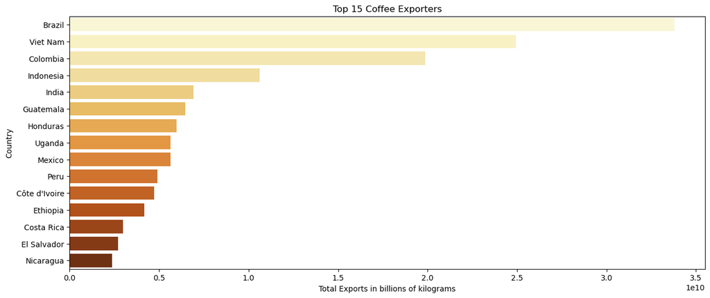

```python
# sorting largest exporters by "Total_export" column
top_fifteen_export_df = coffee_export_df.sort_values(by="Total_export", ascending=False).head(15)

# plotting the top ten exporters
plt.figure(figsize=(15,6))
sns.barplot(data=top_fifteen_export_df,
            x="Total_export",
            y="Country",
            palette="YlOrBr")

plt.title("Top 15 Coffee Exporters")
plt.xlabel("Total Exports in billions of kilograms")
plt.ylabel("Country")
plt.show()
```